# Predicting Pregnant Customers at RetailMart

Based on these values, is it easier to predict *pregnancy* or *non-pregnancy*?

```r
confusionMatrix(random.ds, ds$PREGNANT)
```

```
## Confusion Matrix and Statistics
##
##           Reference
## Prediction   0   1
##          0 482 306
##          1  18 194
##
##                Accuracy : 0.676
##                  95% CI : (0.646, 0.705)
##     No Information Rate : 0.5
##     P-Value [Acc > NIR] : < 2.2e-16
##
##                   Kappa : 0.352
##
##  Mcnemar's Test P-Value : < 2.2e-16
##
##             Sensitivity : 0.9640
##             Specificity : 0.3880
##          Pos Pred Value : 0.6117
##          Neg Pred Value : 0.9151
##              Prevalence : 0.5000
##          Detection Rate : 0.4820
##    Detection Prevalence : 0.7880
##       Balanced Accuracy : 0.6760
##
##        'Positive' Class : 0
##
```

##Sensitivity & Specificity Based on the output of the confusion matrix, identify the values of sensitivity and specificity. Define their meaning and calculate these values with your own instructions, by using *predict*.

```r
# SENSITIVITY: True positives / Total positives. Number of positive samples predicted as positives over the total number of samples predicted as positives.
# SPECIFICITY: True negatives / total negatives. Number of negatuve samples predicted as negatives over the total number of samples predicted as positives.


prediction_of_positives <- predict(tree, data.frame(Folic.Acid = ds$Folic.Acid[ds$PREGNANT == 1], Prenatal.Vitamins = ds$Prenatal.Vitamins[ds$PREGNANT == 1]), type = "class")

prediction_of_negatives <- predict(tree, data.frame(Folic.Acid = ds$Folic.Acid[ds$PREGNANT == 0], Prenatal.Vitamins = ds$Prenatal.Vitamins[ds$PREGNANT == 0]), type = "class")

sensit = length(prediction_of_positives[prediction_of_positives == 1]) / length(random.ds[random.ds==1])
sensit
```

```
## [1] 0.9150943
```

```r
specific = length(prediction_of_negatives[prediction_of_positives == 0])/ length(random.ds[random.ds])
specific
```

```
## [1] 0.306
```

```r
# Alternatively
sensit = length(compare$trueclass[compare$predicted==1 & compare$trueclass==1]) /  length(compare$predicted[compare$predicted==1])
sensit
```

```
## [1] 0.9150943
```

```r
specific = length(compare$trueclass[compare$predicted==0 & compare$trueclass==0]) / length(compare$predicted[compare$predicted==0])
specific
```

```
## [1] 0.6116751
```

```r
#Does not seem to be working  ¯\_(ツ)_/¯
```

#Train a more Complex Model

##Train a Tree

Using library *rpart*, train a decision tree where *pregnant* is the dependent variable and all the other variables are independent variables that feed the model.

```r
ds$PREGNANT <- as.factor(ds$PREGNANT)
tree2 <- rpart(PREGNANT~ ., ds)
tree2
```

```
## n= 1000
##
## node), split, n, loss, yval, (yprob)
##       * denotes terminal node
##
##   1) root 1000 500 0 (0.50000000 0.50000000)
##     2) Folic.Acid< 0.5 894 396 0 (0.55704698 0.44295302)
##       4) Prenatal.Vitamins< 0.5 788 306 0 (0.61167513 0.38832487)
##         8) Maternity.Clothes< 0.5 699 237 0 (0.66094421 0.33905579)
##          16) Stopped.buying.wine< 0.5 631 188 0 (0.70206022 0.29793978)
##            32) Pregnancy.Test< 0.5 600 162 0 (0.73000000 0.27000000)
##              64) Stopped.buying.ciggies< 0.5 561 137 0 (0.75579323 0.24420677)
##               128) Feminine.Hygiene>=0.5 99   5 0 (0.94949495 0.05050505) *
##               129) Feminine.Hygiene< 0.5 462 132 0 (0.71428571 0.28571429)
##                 258) Ginger.Ale< 0.5 437 114 0 (0.73913043 0.26086957) *
##                 259) Ginger.Ale>=0.5 25   7 1 (0.28000000 0.72000000) *
##              65) Stopped.buying.ciggies>=0.5 39  14 1 (0.35897436 0.64102564) *
##            33) Pregnancy.Test>=0.5 31   5 1 (0.16129032 0.83870968) *
##          17) Stopped.buying.wine>=0.5 68  19 1 (0.27941176 0.72058824) *
##         9) Maternity.Clothes>=0.5 89  20 1 (0.22471910 0.77528090) *
##       5) Prenatal.Vitamins>=0.5 106  16 1 (0.15094340 0.84905660)
##        10) Birth.Control>=0.5 10   2 0 (0.80000000 0.20000000) *
##        11) Birth.Control< 0.5 96   8 1 (0.08333333 0.91666667) *
##     3) Folic.Acid>=0.5 106   2 1 (0.01886792 0.98113208) *
```

##Tree Structure Draw and interpret the tree.

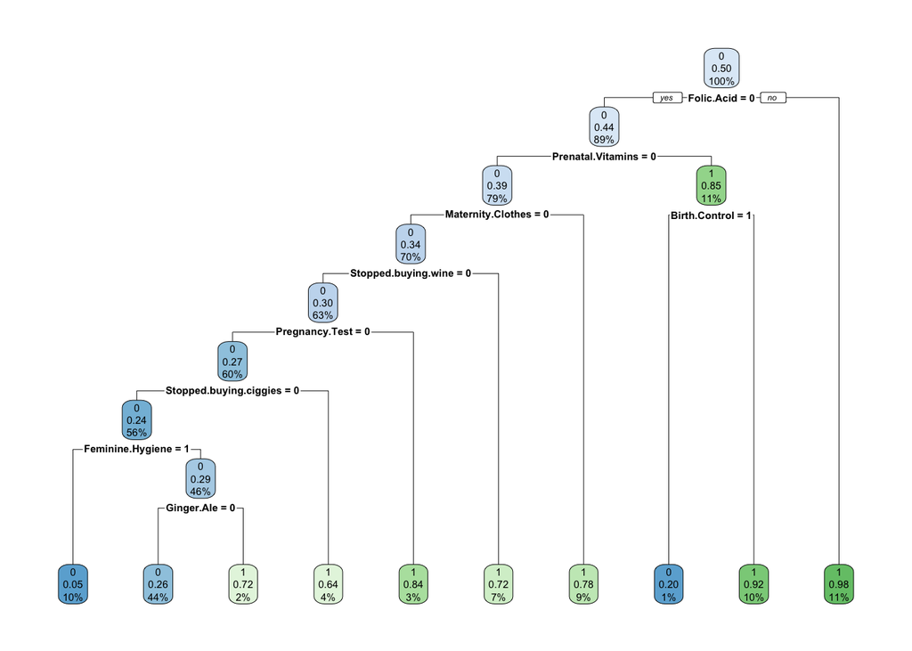

```r
rpart.plot(tree2)
```

##Classification Accuracy Compute the classification accuracy of the tree. Has the previous classification accuracy being improved? Why?

```r
random.ds.2 <- predict(tree2,ds,type = "class")
compare.2 <- data.frame(predicted=random.ds.2, trueclass=ds$PREGNANT)
error.2 <- nrow(compare.2[compare.2$predicted!=compare.2$trueclass,])
ok.2 <- nrow(compare.2[compare.2$predicted==compare.2$trueclass,])
n.2 <- nrow(compare.2)

accuracy.2 <- ok.2 / n.2
accuracy.2
```

```
## [1] 0.804
```

```r
# It has improved significantly (from 0.676 to 0.804) because the algorithm has more data to work with in each sample. Note that folic acid and prenatal vitamins are on top of the tree, which makes them more relevant than the rest of the data
```

##Tree Traversal Convert the left most branch of the tree and the right most branch of the tree into two independent classification rules. How many different classification rules can be extracted from the tree?

##Confusion Matrix Compute the confusion matrix of the tree.

```r
confusionMatrix (random.ds.2, ds$PREGNANT)
```

```
## Confusion Matrix and Statistics
##
##           Reference
## Prediction   0   1
##          0 425 121
##          1  75 379
##
##                Accuracy : 0.804
##                  95% CI : (0.778, 0.8282)
##     No Information Rate : 0.5
##     P-Value [Acc > NIR] : < 2.2e-16
##
##                   Kappa : 0.608
##
##  Mcnemar's Test P-Value : 0.001308
##
##             Sensitivity : 0.8500
##             Specificity : 0.7580
##          Pos Pred Value : 0.7784
##          Neg Pred Value : 0.8348
##              Prevalence : 0.5000
##          Detection Rate : 0.4250
##    Detection Prevalence : 0.5460
##       Balanced Accuracy : 0.8040
##
##        'Positive' Class : 0
##
```

##Sensitivity & Specificity Identify the value of sensitivity and specificity. In what sense have the results improved?

#Train-Test Models To avoid optimistic estimates of the accuracy of the model, we’ll train the tree with a training dataset, which will contain 75% of the examples of the original dataset. We’ll keep the remaining 25% examples in the test dataset.